# analysis_supertest_2

#### Import packages

```python
import pandas as pd
import numpy as np
import math
import matplotlib.pyplot as plt
from matplotlib.ticker import FuncFormatter
%matplotlib inline
```

#### Import cleaned data

```python
# Import data.
clean_df = pd.read_csv('supertest_fullcompletes_2.csv', encoding='latin-1')
```

```python
# Define sample size for future use in the script as a variable called N
N = len(clean_df)
N
```

```
30
```

```python
list(clean_df.columns.values) # For reference later when picking out data in specific column
```

```
['Unnamed: 0',
 'Participant No.',
 'CustomID',
 'IP Address',
 'Date Started',
 'Date Completed',
 'User Agent',
 'Total Time Spent',
 'Avg Time Taken',
 'Avg Page Views',
 '1. Task. How to use the task panel',
 'Page Views',
 'Time Spent',
 '2. Task. Task 1 - Employer details',
 'Page Views.1',
 'Time Spent.1',
 '7. Task. Task 2 - Employee details',
 'Page Views.2',
 'Time Spent.2',
 '17. Task. Task 3 Understanding of results',
 'Page Views.3',
 'Time Spent.3',
 'This tool calculates your super guarantee charge (SGC) liability as an employer. What did you understand SGC to mean? ',
 "After completing the first page of the tool, how do you expect the ATO to use the information you're providing? Please select all that apply:",
 'Other, please specify',
 'The difference between "Full legal name" and "Authorised contact name" was clear.',
 'Please tell us about any issues you encountered when completing this task.',
 'According to your results, you need to pay the following super amount (to the nearest dollar) for Jane:',
 "I'm confident I got the right answer.",
 'I was given enough information about the documentation required to complete this form.',
 'I found the language used in the tool easy to understand.',
 'Overall I found this tool easy to use.',
 'I found it easy to navigate through this form.',
 'The buttons on this form behaved the way I expected.',
 'What is your preference for entering employee salaries and wages?',
 'Other, please specify.1',
 'Select any of the help features you used. Please choose all that apply:',
 'If you used the help features: I found it easy to locate the help icon at the end of each question.',
 'If you used the help features: I found the help content useful.',
 'I was aware that there was an additional help button at the top of the page.',
 'Please tell us about any issues you encountered when completing this task..1',
 'Based on the information provided on screen, what are the next steps you would take? Please select all that apply:',
 'Other, please specify.2',
 'If you were going to send your report to the ATO, how would you do that?',
 'I found the summary easy to understand.',
 'I feel confident about the next steps I need to take after using this calculator.',
 'Please tell us about any issues you encountered when completing this task..2',
 'Which of the following best describes your role? Please select all that apply.',
 'Other, please specify.3',
 'How many staff members does your business/the business you work at employ?',
 'Are you an ATO employee?']
```

```python
clean_df
```

|  | Unnamed: 0 | Participant No. | CustomID | IP Address | Date Started | Date Completed | User Agent | Total Time Spent | Avg Time Taken | Avg Page Views | ... | Based on the information provided on screen, what are the next steps you would take? Please select all that apply: | Other, please specify.2 | If you were going to send your report to the ATO, how would you do that? | I found the summary easy to understand. | I feel confident about the next steps I need to take after using this calculator. | Please tell us about any issues you encountered when completing this task..2 | Which of the following best describes your role? Please select all that apply. | Other, please specify.3 | How many staff members does your business/the business you work at employ? | Are you an ATO employee? |
| --- | --- | --- | --- | --- | --- | --- | --- | --- | --- | --- | --- | --- | --- | --- | --- | --- | --- | --- | --- | --- | --- |
| 0 | 3 | Participant 19 | NaN | 180.149.192.139 | 09/22/16 14:49 | 09/22/16 15:13 | Mozilla/5.0 (Windows NT 6.1; WOW64; rv:41.0) G... | 1422 secs | 137.0 | 2.0 | ... | Print and sign the generated statement and sen... | NaN | I'm unsure | Disagree | Disagree | the terms you use are not consistent and you t... | Small Business | NaN | 1 to 10 | No |
| 1 | 4 | Participant 26 | NaN | 108.171.134.160 | 09/23/16 15:18 | 09/23/16 15:24 | Mozilla/5.0 (Windows NT 6.1; WOW64; Trident/7.... | 378 secs | 37.8 | 1.3 | ... | Print and sign the generated statement and sen... | NaN | Generate an SGC statement and print the statement | Agree | Agree | NaN | Tax professional (BAS agent, Tax agent, Legal ... | NaN | over 100 | No |
| 2 | 8 | Participant 32 | NaN | 116.212.243.106 | 09/23/16 15:23 | 09/23/16 15:27 | Mozilla/5.0 (Windows NT 6.3; WOW64; Trident/7.... | 273 secs | 7.5 | 1.0 | ... | Print and sign the generated statement and sen... | NaN | Use the print-friendly button to print the sum... | Agree | Agree | NaN | Small Business | NaN | 11 to 50 | No |
| 3 | 18 | Participant 67 | NaN | 1.124.49.5 | 09/25/16 12:24 | 09/25/16 12:47 | Mozilla/5.0 (Windows NT 10.0; Win64; x64) Appl... | 1396 secs | 138.3 | 2.0 | ... | Print and sign the generated statement and sen... | NaN | I'm unsure | Neither agree nor disagree | Disagree | No ability to scroll down using the side bar. ... | Tax professional (BAS agent, Tax agent, Legal ... | NaN | 1 to 10 | No |
| 4 | 19 | Participant 70 | NaN | 61.8.13.254 | 09/26/16 7:36 | 09/26/16 8:31 | Mozilla/5.0 (Windows NT 6.3; WOW64) AppleWebKi... | 3254 secs | 683.5 | 2.0 | ... | Generate a statement and save it, Print and si... | Pay the amount outstanding as per instructions | Generate an SGC statement and print the statement | Agree | Agree | No particular issues. | Tax professional (BAS agent, Tax agent, Legal ... | NaN | 11 to 50 | No |
| 5 | 20 | Participant 73 | NaN | 101.179.179.209 | 09/26/16 8:04 | 09/26/16 8:17 | Mozilla/5.0 (Windows NT 6.1; WOW64; Trident/7.... | 758 secs | 120.3 | 1.8 | ... | Generate a statement and save it, Print and si... | NaN | Generate an SGC statement and print the statement | Agree | Agree | NaN | Tax professional (BAS agent, Tax agent, Legal ... | NaN | 1 to 10 | No |
| 6 | 21 | Participant 74 | NaN | 203.214.1.201 | 09/26/16 9:03 | 09/26/16 9:13 | Mozilla/5.0 (Windows NT 10.0; Win64; x64) Appl... | 568 secs | 75.3 | 1.5 | ... | Print and sign the generated statement and sen... | NaN | Use the print-friendly button to print the sum... | Agree | Agree | NaN | Tax professional (BAS agent, Tax agent, Legal ... | NaN | 11 to 50 | No |
| 7 | 22 | Participant 77 | NaN | 60.241.104.209 | 09/26/16 9:56 | 09/26/16 10:49 | Mozilla/5.0 (Windows NT 6.1; Trident/7.0; MATP... | 3181 secs | 406.0 | 1.5 | ... | Generate a statement and save it, Print and si... | NaN | Generate an SGC statement and print the statement | Agree | Agree | NaN | Tax professional (BAS agent, Tax agent, Legal ... | NaN | 1 to 10 | No |
| 8 | 23 | Participant 79 | NaN | 115.70.216.32 | 09/26/16 10:05 | 09/26/16 10:17 | Mozilla/5.0 (Windows NT 6.1) AppleWebKit/537.3... | 713 secs | 73.0 | 2.0 | ... | Generate a statement and save it, Print and si... | Pay the super guarantee charge amount | Generate an SGC statement and print the statement | Agree | Agree | NaN | Not for Profit | NaN | 1 to 10 | No |
| 9 | 24 | Participant 89 | NaN | 203.45.5.159 | 09/26/16 14:31 | 09/26/16 14:41 | Mozilla/5.0 (Windows NT 5.1; rv:48.0) Gecko/20... | 618 secs | 67.0 | 1.0 | ... | Contact the ATO or tax agent | NaN | Generate an SGC statement and print the statement | Disagree | Neither agree nor disagree | Results based on incorrect information. There ... | Small Business | NaN | 1 to 10 | No |
| 10 | 25 | Participant 91 | NaN | 180.149.192.139 | 09/26/16 15:34 | 09/26/16 15:42 | Mozilla/5.0 (Windows NT 6.1; WOW64; rv:41.0) G... | 494 secs | 68.8 | 1.3 | ... | Print and sign the generated statement and sen... | NaN | Generate an SGC statement and print the statement | Agree | Agree | no issues | NaN | ATO internal staff | NaN | Yes |
| 11 | 26 | Participant 95 | NaN | 115.166.60.199 | 09/27/16 0:08 | 09/27/16 0:27 | Mozilla/5.0 (Windows NT 10.0; Win64; x64) Appl... | 1128 secs | 164.0 | 2.0 | ... | Print and sign the generated statement and sen... | NaN | Generate an SGC statement and print the statement | Strongly agree | Strongly agree | Nil | Tax professional (BAS agent, Tax agent, Legal ... | NaN | 11 to 50 | No |
| 12 | 27 | Participant 97 | NaN | 110.175.92.146 | 09/27/16 9:34 | 09/27/16 9:42 | Mozilla/5.0 (Windows NT 6.1; WOW64) AppleWebKi... | 468 secs | 64.5 | 1.3 | ... | Contact the ATO or tax agent | NaN | None of the above | Disagree | Neither agree nor disagree | NaN | Not for Profit | NaN | 1 to 10 | No |
| 13 | 28 | Participant 98 | NaN | 175.33.127.135 | 09/27/16 10:23 | 09/27/16 10:56 | Mozilla/5.0 (Windows NT 10.0; Win64; x64) Appl... | 1960 secs | 332.8 | 4.0 | ... | Generate a statement and save it, Give this in... | NaN | Generate an SGC statement and print the statement | Agree | Agree | NaN | Small Business | NaN | 1 to 10 | No |
| 14 | 29 | Participant 106 | NaN | 203.59.135.37 | 09/27/16 16:15 | 09/27/16 16:28 | Mozilla/5.0 (Windows NT 6.1; Win64; x64) Apple... | 769 secs | 108.3 | 2.3 | ... | Generate a statement and save it, Print and si... | I use the Super Clearing house for employee su... | Use the print-friendly button to print the sum... | Agree | Agree | NaN | Not for Profit | NaN | 1 to 10 | No |
| 15 | 30 | Participant 117 | NaN | 150.101.115.206 | 09/30/16 9:01 | 09/30/16 9:17 | Mozilla/5.0 (Macintosh; Intel Mac OS X 10_12) ... | 974 secs | 123.0 | 1.5 | ... | Generate a statement and save it | NaN | Use the print-friendly button to print the sum... | Agree | Neither agree nor disagree | NaN | Individual | NaN | NaN | Yes |
| 16 | 31 | Participant 120 | NaN | 120.151.198.75 | 10/02/2016 15:57 | 10/02/2016 16:13 | Mozilla/5.0 (Windows NT 10.0; WOW64) AppleWebK... | 941 secs | 120.8 | 2.8 | ... | Generate a statement and save it, Print and si... | Pay the outstanding guaranteed charge | Generate an SGC statement and print the statement | Strongly agree | Strongly agree | NaN | Tax professional (BAS agent, Tax agent, Legal ... | NaN | 1 to 10 | No |
| 17 | 32 | Participant 122 | NaN | 180.149.192.135 | 10/03/2016 15:53 | 10/03/2016 16:01 | Mozilla/5.0 (Windows NT 6.1; WOW64; rv:41.0) G... | 475 secs | 56.0 | 2.0 | ... | Generate a statement and save it, Give this in... | NaN | Use the print-friendly button to print the sum... | Neither agree nor disagree | Disagree | NaN | Individual | NaN | NaN | Yes |
| 18 | 33 | Participant 124 | NaN | 101.183.198.92 | 10/04/2016 11:43 | 10/04/2016 12:01 | Mozilla/5.0 (Windows NT 6.3; WOW64; Trident/7.... | 1037 secs | 67.8 | 1.8 | ... | Generate a statement and save it, Print and si... | NaN | Generate an SGC statement and print the statement | Agree | Agree | NaN | Small Business | NaN | 1 to 10 | No |
| 19 | 34 | Participant 125 | NaN | 101.187.205.156 | 10/04/2016 12:09 | 10/04/2016 12:34 | Mozilla/5.0 (Windows NT 6.1; WOW64) AppleWebKi... | 1465 secs | 219.5 | 2.8 | ... | Print and sign the generated statement and sen... | NaN | Generate an SGC statement and print the statement | Agree | Disagree | Who do i pay, the ATO or super fund or both. S... | Tax professional (BAS agent, Tax agent, Legal ... | NaN | 1 to 10 | No |
| 20 | 35 | Participant 131 | NaN | 180.149.192.135 | 10/04/2016 19:42 | 10/04/2016 19:47 | Mozilla/5.0 (Windows NT 6.1; WOW64; rv:41.0) G... | 280 secs | 24.0 | 1.3 | ... | Print and sign the generated statement and sen... | NaN | None of the above | Neither agree nor disagree | Neither agree nor disagree | why cant i do online | Small Business | NaN | 11 to 50 | No |
| 21 | 36 | Participant 137 | NaN | 58.108.173.56 | 10/06/2016 14:50 | 10/06/2016 15:01 | Mozilla/5.0 (Windows NT 6.1; Win64; x64) Apple... | 630 secs | 76.3 | 2.3 | ... | Print and sign the generated statement and sen... | NaN | Generate an SGC statement and print the statement | Strongly agree | Strongly agree | I wasn't able to complete the tasks. | Small Business | NaN | 1 to 10 | No |
| 22 | 37 | Participant 139 | NaN | 198.103.184.76 | 10/06/2016 23:45 | 10/07/2016 0:31 | Mozilla/5.0 (Windows NT 6.1; WOW64; Trident/7.... | 2730 secs | 228.8 | 1.0 | ... | Generate a statement and save it, Print and si... | NaN | Use the print-friendly button to print the sum... | Disagree | Disagree | I made lot of comments that were erased when I... | Tax professional (BAS agent, Tax agent, Legal ... | NaN | 1 to 10 | No |
| 23 | 38 | Participant 142 | NaN | 180.149.192.136 | 10/07/2016 11:14 | 10/07/2016 11:20 | Mozilla/5.0 (Windows NT 6.1; WOW64; Trident/7.... | 307 secs | 23.5 | 1.0 | ... | Print and sign the generated statement and sen... | NaN | Generate an SGC statement and print the statement | Disagree | Disagree | NaN | Small Business | NaN | 1 to 10 | Yes |
| 24 | 39 | Participant 154 | NaN | 180.149.192.134 | 10/12/2016 14:06 | 10/12/2016 14:17 | Mozilla/5.0 (Windows NT 6.1; WOW64; rv:41.0) G... | 669 secs | 85.0 | 1.5 | ... | Print and sign the generated statement and sen... | NaN | Generate an SGC statement and print the statement | Agree | Agree | NaN | NaN | ATO staff | over 100 | Yes |
| 25 | 40 | Participant 161 | NaN | 205.156.88.233 | 10/14/16 12:25 | 10/14/16 12:40 | Mozilla/5.0 (Windows NT 6.1; WOW64; rv:45.0) G... | 918 secs | 87.8 | 1.3 | ... | Print and sign the generated statement and sen... | NaN | Generate an SGC statement and print the statement | Neither agree nor disagree | Agree | NaN | Small Business | NaN | 11 to 50 | No |
| 26 | 41 | Participant 165 | NaN | 49.195.82.86 | 10/16/16 21:00 | 10/16/16 21:08 | Mozilla/5.0 (iPhone; CPU iPhone OS 10_0_2 like... | 489 secs | 43.8 | 1.0 | ... | NaN | NaN | NaN | NaN | NaN | NaN | NaN | NaN | NaN | NaN |
| 27 | 42 | Participant 176 | NaN | 119.225.114.60 | 10/18/16 14:40 | 10/18/16 14:48 | Mozilla/5.0 (Macintosh; Intel Mac OS X 10.11; ... | 514 secs | 41.3 | 1.0 | ... | Print and sign the generated statement and sen... | NaN | I'm unsure | Neither agree nor disagree | Neither agree nor disagree | NaN | Individual | NaN | NaN | Yes |
| 28 | 43 | Participant 191 | NaN | 180.149.192.133 | 10/26/16 19:01 | 10/26/16 19:17 | Mozilla/5.0 (Windows NT 6.1; WOW64; Trident/7.... | 987 secs | 131.5 | 2.3 | ... | Print and sign the generated statement and sen... | NaN | Use the print-friendly button to print the sum... | Disagree | Disagree | NaN | Small Business | NaN | 1 to 10 | No |
| 29 | 44 | Participant 193 | NaN | 101.179.231.162 | 10/27/16 7:15 | 10/27/16 7:31 | Mozilla/5.0 (iPad; CPU OS 10_0_2 like Mac OS X... | 996 secs | 119.0 | 4.3 | ... | Generate a statement and save it, Print and si... | NaN | Generate an SGC statement and print the statement | Disagree | Agree | The help buttons didn't ore next to the summar... | Small Business | NaN | 1 to 10 | Yes |

30 rows × 51 columns

#### Define functions for plotting the graphs

```python
# Function for basic bar graph
def grapher(df, cols, title, location):
    plot_df = df[cols]
    colours=['#42bac7','#074f5f','#9d9d9c']
    ax = plot_df.plot(kind='bar', legend=False, color=colours, edgecolor = "none", rot = 0)
    ax.set_xticklabels(list(plot_df[cols].index))
    ax.set_ylim([0,1])
    ax.yaxis.set_major_formatter(FuncFormatter(lambda y, _: '{:.0%}'.format(y)))
    ax.set_title(title)
    plt.savefig(location+title+".svg")
```

```python
# Function for bar graph with error bars
def grapher_errorbar(df, cols, title, cis, labels, location):
    plot_df = df[cols]
    colours=['#9d9d9c','#074f5f','#42bac7']
    ax = plot_df.plot(kind='bar', legend=False, color=colours, edgecolor = "none", rot = 0, yerr=cis)
    ax.set_xticklabels(list(plot_df[cols].index))
    ax.set_ylim([0,1])
    ax.yaxis.set_major_formatter(FuncFormatter(lambda y, _: '{:.0%}'.format(y)))
    ax.set_title(title)
    if not(not labels):
        ax.legend(labels,loc='best')
    plt.savefig(location+title+".svg")
```

```python
# Function for horizontal graph
def grapher_horizontal(df, cols, title, location):
    plot_df = df[cols]
    colours=['#9d9d9c','#074f5f','#42bac7']
    ax = plot_df.plot(kind='barh', legend=False, color=colours, edgecolor = "none", rot = 0)
    ax.set_yticklabels(list(plot_df[cols].index))
    ax.set_xlim([0,1])
    ax.xaxis.set_major_formatter(FuncFormatter(lambda y, _: '{:.0%}'.format(y)))
    ax.set_title(title)
    plt.savefig(location+title+".svg")
```

```python
# Function for bar graph with stacked data sets
def grapher_stacked(df, cols, title, labels, cis, location):
    plot_df = df[cols].unstack(level=0).sort_index(ascending=False)
    colours=['#42bac7','#074f5f','#9d9d9c']
    ax = plot_df.plot(kind='bar', legend=True, color=colours, edgecolor = "none", rot = 0, yerr=cis)
    ax.set_xticklabels(list(plot_df.index))
    ax.set_ylim([0,1])
    ax.yaxis.set_major_formatter(FuncFormatter(lambda y, _: '{:.0%}'.format(y)))
    ax.set_title(title)
    ax.legend(labels,loc='best')
    plt.savefig(location+title+".svg")
```

```python
# Function for graphs with stacked data sets
def grapher_stacked_N(df, cols, title, location):
    plot_df = df[cols].unstack(level=1)
    #plot_df = task2_results[['Task 2 (%)']]
    colours=['#42bac7','#074f5f','#9d9d9c']
    ax = plot_df.plot(kind='bar', legend=True, color=colours, edgecolor = "none", rot = 0)
    ax.set_xticklabels(list(plot_df[cols].index))
    ax.set_title(title)
    plt.savefig(location+title+".svg")
```

## Compute Task Results

```python
# Create results DataFrame for all tasks.

results = []

tasks = ['2. Task. Task 1 - Employer details', '7. Task. Task 2 - Employee details', '17. Task. Task 3 Understanding of results']
for t in tasks:
    results.append(pd.DataFrame(clean_df[t].value_counts()))
    results.append(pd.DataFrame(clean_df[t].value_counts(normalize=True)))

results = pd.concat(results, axis=1)
results.index.names = ['Result']
results.columns = ['Task 1 (N)', 'Task 1 (%)','Task 2 (N)', 'Task 2 (%)', 'Task 3 (N)', 'Task 3 (%)' ]

results = results.reindex(['success', 'fail', 'abandon'])
results
```

| Result | Task 1 (N) | Task 1 (%) | Task 2 (N) | Task 2 (%) | Task 3 (N) | Task 3 (%) |
| --- | --- | --- | --- | --- | --- | --- |
| success | 20 | 0.666667 | 2 | 0.066667 | 27 | 0.900000 |
| fail | 9 | 0.300000 | 25 | 0.833333 | 2 | 0.066667 |
| abandon | 1 | 0.033333 | 3 | 0.100000 | 1 | 0.033333 |

#### Calculate confidence intervals

```python
# For small sample size adjustment
# Adjust the sample size, N
def adjust_n(N):
    return N+(1.96**2)

# Adjust the proportion of successes, p
def adjust_p(p, N):
    return (p+1.92)/(N+3.84)

Task1_p = results['Task 1 (N)']['success']
Task2_p = results['Task 2 (N)']['success']
Task3_p = results['Task 3 (N)']['success']

# CONFIDENCE INTERVAL FORMULA:
# CI_95 = 1.96 * SQRT((adjusted_p * (1 - adjusted_p))/adjusted_n)
Task1_CI = 1.96 * np.sqrt((adjust_p(Task1_p,N) * (1 - adjust_p(Task1_p,N)))/adjust_n(N))
Task2_CI = 1.96 * np.sqrt((adjust_p(Task2_p,N) * (1 - adjust_p(Task2_p,N)))/adjust_n(N))
Task3_CI = 1.96 * np.sqrt((adjust_p(Task3_p,N) * (1 - adjust_p(Task3_p,N)))/adjust_n(N))


# Print confidence intervals for reference.
print('Task 1 Confidence Interval: ',Task1_CI)
print('Task 2 Confidence Interval: ',Task1_CI)
print('Task 3 Confidence Interval: ',Task3_CI)
```

```
Task 1 Confidence Interval:  0.160938028039
Task 2 Confidence Interval:  0.160938028039
Task 3 Confidence Interval:  0.118763221292
```

#### Plot task completion rates with confidence intervals.

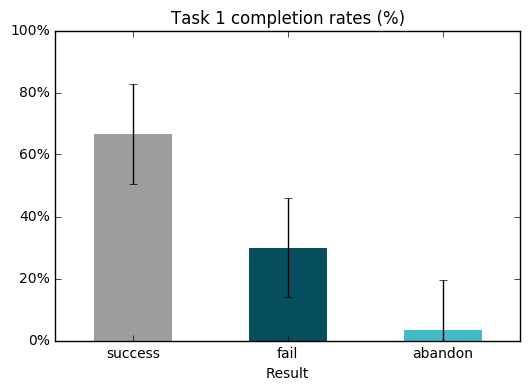

```python
grapher_errorbar(results, ['Task 1 (%)'], 'Task 1 completion rates (%)', [Task1_CI, Task1_CI, Task1_CI],[], 'super_test2_graphs/')
```

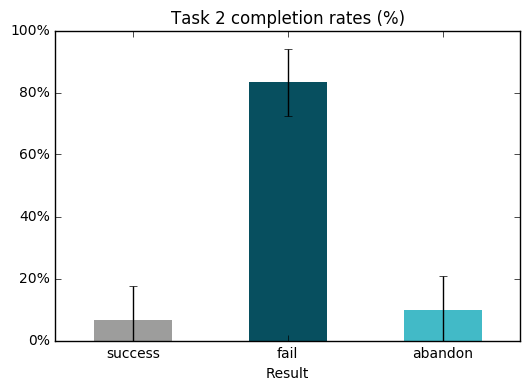

```python
grapher_errorbar(results, ['Task 2 (%)'], 'Task 2 completion rates (%)', [Task2_CI, Task2_CI, Task2_CI],[], 'super_test2_graphs/')
```

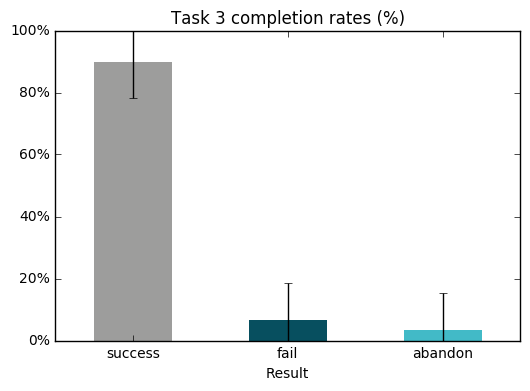

```python
grapher_errorbar(results, ['Task 3 (%)'], 'Task 3 completion rates (%)', [Task3_CI, Task3_CI, Task3_CI],[], 'super_test2_graphs/')
```

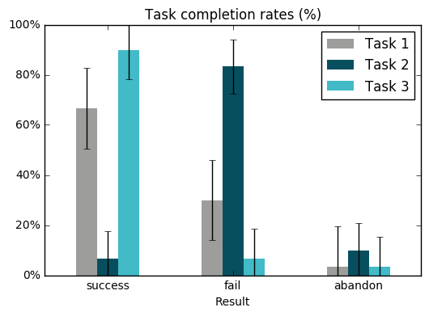

```python
errors = pd.DataFrame(np.array([[Task1_CI,Task2_CI,Task3_CI],[Task1_CI,Task2_CI,Task3_CI],[Task1_CI,Task2_CI,Task3_CI]]), index=['success', 'fail', 'abandon'], columns=['Task 1 (%)','Task 2 (%)','Task 3 (%)'])
grapher_errorbar(results, ['Task 1 (%)','Task 2 (%)','Task 3 (%)'], 'Task completion rates (%)',errors,['Task 1','Task 2','Task 3'], 'super_test2_graphs/')
```

## Demographic Breakdowns

### Breakdown task results into ATO Employees vs NON ATO Employees

```python
employee_breakdown = []

employee_breakdown.append(pd.DataFrame(clean_df['Are you an ATO employee?'].value_counts()))
employee_breakdown.append(pd.DataFrame(clean_df['Are you an ATO employee?'].value_counts(normalize=True)))

employee_breakdown = pd.concat(employee_breakdown, axis=1)
employee_breakdown.columns = ['Are you an ATO employee? (N)','Are you an ATO employee? (%)']

employee_breakdown
```

|  | Are you an ATO employee? (N) | Are you an ATO employee? (%) |
| --- | --- | --- |
| No | 22 | 0.758621 |
| Yes | 7 | 0.241379 |

**NOTE: THE MAJORITY OF PARTICPANTS WERE NOT ATO EMPLOYEES. THE ATO EMPLOYEE GROUP IS TOO SMALL TO BE STATISTICALLY SIGNIFICANT. NOT CALCULATING RESULTS FOR THE TWO DIFFERENT GROUPS**

### Breakdown task results for different demographics

```python
# First replace NaN with Other (will need analysis of Other field)
temp = clean_df['Which of the following best describes your role? Please select all that apply.'].fillna('Other')

broken_down = [sub.split(",") for sub in temp]
reshaped_list = [item.lstrip() for sublist in broken_down  for item in sublist]
test_df = pd.DataFrame(reshaped_list)
demo_ms_results = []
demo_ms_results.append(pd.DataFrame(test_df[0].value_counts()))
demo_ms_results.append(pd.DataFrame(test_df[0].value_counts()/len(clean_df)))
demo_ms_results = pd.concat(demo_ms_results, axis=1)
demo_ms_results.columns = ['Number','Fraction (from Sample size)']
demo_ms_results
```

|  | Number | Fraction (from Sample size) |
| --- | --- | --- |
| Small Business | 11 | 0.366667 |
| Tax agent | 10 | 0.333333 |
| Legal or Insolvency practitioner) | 10 | 0.333333 |
| Tax professional (BAS agent | 10 | 0.333333 |
| Other | 3 | 0.100000 |
| Individual | 3 | 0.100000 |
| Not for Profit | 3 | 0.100000 |

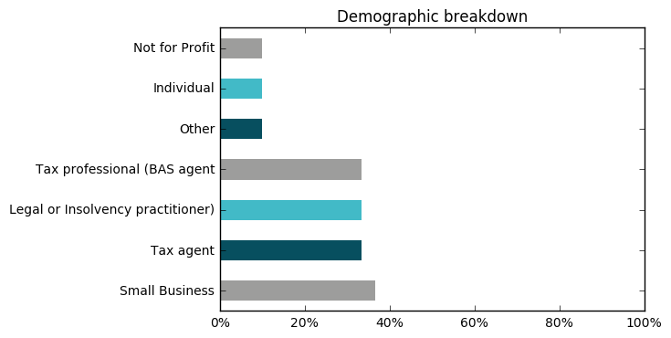

```python
grapher_horizontal(demo_ms_results, ['Fraction (from Sample size)'], 'Demographic breakdown', 'super_test2_graphs/')
```

**AGAIN THE SAMPLE SIZES ARE TOO SMALL TO BE SIGNIFICANT. NOT BREAKING DOWN TASK SUCCESS RATES FOR THE DIFFERENT GROUPS**

### Number of employees in the participants business (or business they work for)

```python
business_size_breakdown = []

temp = pd.DataFrame(clean_df['How many staff members does your business/the business you work at employ?'].fillna('N/A'))

business_size_breakdown.append(pd.DataFrame(temp['How many staff members does your business/the business you work at employ?'].value_counts()))
business_size_breakdown.append(pd.DataFrame(temp['How many staff members does your business/the business you work at employ?'].value_counts(normalize=True)))

business_size_breakdown = pd.concat(business_size_breakdown, axis=1)
business_size_breakdown.columns = ['Business size (N)','Business size (%)']

business_size_breakdown['Business size (%)'].fillna('N/A')

business_size_breakdown
```

|  | Business size (N) | Business size (%) |
| --- | --- | --- |
| 1 to 10 | 17 | 0.566667 |
| 11 to 50 | 6 | 0.200000 |
| N/A | 5 | 0.166667 |
| over 100 | 2 | 0.066667 |

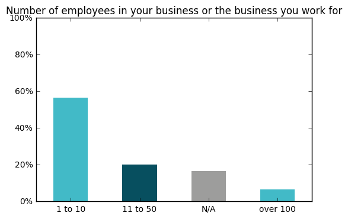

```python
grapher(business_size_breakdown, ['Business size (%)'], 'Number of employees in your business or the business you work for', 'super_test2_graphs/')
```

## Task 1 Questions

### This tool calculates your super guarantee charge... What did you understand SGC to mean?

```python
# First break the strings up with , as the delimiter, and then tally the results as usual.
# Also replace NaN's with Other and remove null values

temp = clean_df['This tool calculates your super guarantee charge (SGC) liability as an employer. What did you understand SGC to mean? '].fillna('Other')
broken_down = [sub.split(",") for sub in temp]
reshaped_list = [item.lstrip() for sublist in broken_down  for item in sublist]
set(reshaped_list)
test_df= pd.DataFrame(reshaped_list)

sgc_results = []
sgc_results.append(pd.DataFrame(test_df[0].value_counts()))
sgc_results.append(pd.DataFrame(test_df[0].value_counts()/len(clean_df)))

sgc_results = pd.concat(sgc_results, axis=1)
sgc_results.columns = ['Number','Fraction (from Sample size)']
sgc_results.index.name = 'WHAT DID YOU UNDERSTAND SGC TO MEAN?'

sgc_results
```

| WHAT DID YOU UNDERSTAND SGC TO MEAN? | Number | Fraction (from Sample size) |
| --- | --- | --- |
| The amount of super I am required to pay for my employee/s | 19 | 0.633333 |
| The penalty amount I am obliged to pay the ATO if I miss super payments for my employee/s | 9 | 0.300000 |
| I'm unsure | 6 | 0.200000 |
| An administrative fee I am obliged to pay the ATO to process late super payments for my employee/s | 5 | 0.166667 |
| Interest on any outstanding super I have not paid for my employee/s | 5 | 0.166667 |
| Other | 1 | 0.033333 |

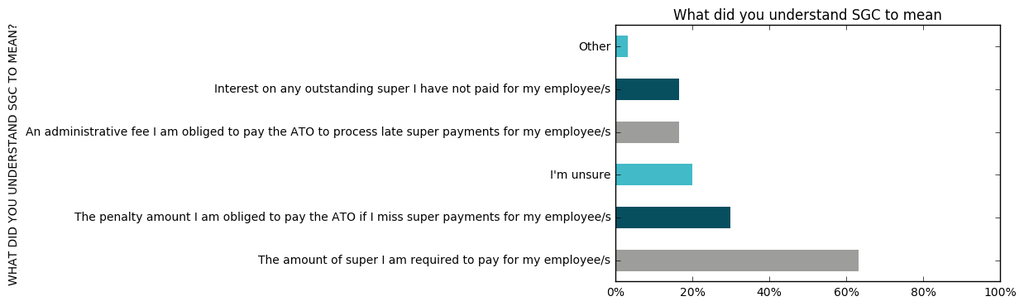

```python
grapher_horizontal(sgc_results, ['Fraction (from Sample size)'], 'What did you understand SGC to mean', 'super_test2_graphs/')
```

### After completing the first page of the tool, how do you expect the ATO to use the information you're providing?

```python
# First break the strings up with , as the delimiter, and then tally the results as usual.
# Also replace NaN's with Other and remove null values

temp = clean_df['After completing the first page of the tool, how do you expect the ATO to use the information you\'re providing? Please select all that apply:'].fillna('Other')
broken_down = [sub.split(",") for sub in temp]
reshaped_list = [item.lstrip() for sublist in broken_down  for item in sublist]
set(reshaped_list)
test_df= pd.DataFrame(reshaped_list)

info_results = []
info_results.append(pd.DataFrame(test_df[0].value_counts()))
info_results.append(pd.DataFrame(test_df[0].value_counts()/len(clean_df)))

info_results = pd.concat(info_results, axis=1)
info_results.columns = ['Number','Fraction (from Sample size)']
info_results.index.name = 'AFTER COMPLETING THE FIRST PAGE - INFORMATION USE EXPECTATIONS'

info_results
```

| AFTER COMPLETING THE FIRST PAGE - INFORMATION USE EXPECTATIONS | Number | Fraction (from Sample size) |
| --- | --- | --- |
| The ATO will keep a record of the information I provide | 14 | 0.466667 |
| The ATO will contact me if I owe super | 12 | 0.400000 |
| The information will be sent to the super fund/s in question | 8 | 0.266667 |
| Other | 5 | 0.166667 |
| The information will be sent to the employee/s in question | 3 | 0.100000 |

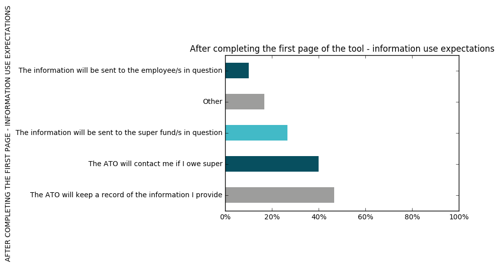

```python
grapher_horizontal(info_results, ['Fraction (from Sample size)'], 'After completing the first page of the tool - information use expectations', 'super_test2_graphs/')
```

```python
# Other specified expectations for Information Use
info_expect = []

info_expect.append(pd.DataFrame(clean_df['Other, please specify']))
info_expect = pd.concat(info_expect, axis=1)
info_expect = info_expect[info_expect['Other, please specify'].notnull()]

info_expect
```

|  | Other, please specify |
| --- | --- |
| 3 | Whether I owe super or not will be available a... |
| 13 | unsure |
| 15 | unsure |
| 21 | The only thing I filled in was the fake busine... |
| 25 | its jsut a calacultor for me to use to determi... |

```python
info_expect['Other, please specify'][3]
```

```
'Whether I owe super or not will be available as a document to save or print as soon as the I have finished entering the informaiton.'
```

```python
info_expect['Other, please specify'][21]
```

```
'The only thing I filled in was the fake business info - there was no tool?'
```

```python
info_expect['Other, please specify'][25]
```

```
'its jsut a calacultor for me to use to determine if paid correctly'
```

### Task1 Likert Questions

```python
# List of the standard likert scale question (e.g. agree, disagree...)
task1_agree_scale = ['The difference between "Full legal name" and "Authorised contact name" was clear.']

# Produce statistics for standard likert scale questions (with all scales)
task1_likert_results = []

for q in task1_agree_scale:
    task1_likert_results.append(pd.DataFrame(clean_completes_df[q].value_counts()))
    task1_likert_results.append(pd.DataFrame(clean_completes_df[q].value_counts(normalize=True)))

# Produce statistics for standard likert scale questions (with compacted scales)
task1_help_agree_likert_results = []

for q in task1_agree_scale:
    temp = clean_completes_df[q].replace('Strongly agree', 'Agree', regex=True)
    temp = temp.replace('Strongly disagree', 'Disagree', regex=True)
    task1_help_agree_likert_results.append(pd.DataFrame(temp.value_counts()))
    task1_help_agree_likert_results.append(pd.DataFrame(temp.value_counts(normalize=True)))

task1_help_agree_likert_results = pd.concat(task1_help_agree_likert_results , axis=1) # convert the flat list dataframe to columns
task1_help_agree_likert_results = task1_help_agree_likert_results.reindex(['Agree', 'Neither agree nor disagree', 'Disagree'])

# Rename column titles
task1_help_agree_likert_results.columns = ['The difference between "Full legal name" and "Authorised contact name" was clear. (N)',
              'The difference between "Full legal name" and "Authorised contact name" was clear. (%)']
task1_help_agree_likert_results
```

|  | The difference between "Full legal name" and "Authorised contact name" was clear. (N) | The difference between "Full legal name" and "Authorised contact name" was clear. (%) |
| --- | --- | --- |
| Agree | 11 | 0.379310 |
| Neither agree nor disagree | 6 | 0.206897 |
| Disagree | 12 | 0.413793 |

```
Mean:  0.3333333333333333
Standard Deviation:  0.1108465604711834
```

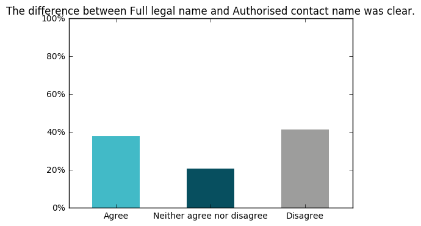

```python
print('Mean: ', task1_help_agree_likert_results['The difference between "Full legal name" and "Authorised contact name" was clear. (%)'].mean())
print('Standard Deviation: ', task1_help_agree_likert_results['The difference between "Full legal name" and "Authorised contact name" was clear. (%)'].std())

grapher(task1_help_agree_likert_results, ['The difference between "Full legal name" and "Authorised contact name" was clear. (%)'], 'The difference between Full legal name and Authorised contact name was clear.', 'super_test2_graphs/')
```

## Task 2 Questions

### According to your results, you need to pay the following super amount for Jane

```python
# Check there is no missing data in the column.
len(clean_df['According to your results, you need to pay the following super amount (to the nearest dollar) for Jane:'].notnull())
```

```
30
```

```python
# How much SGC does Jane owe?
superamt_results = []
superamt_results.append(pd.DataFrame(clean_df['According to your results, you need to pay the following super amount (to the nearest dollar) for Jane:'].value_counts()))
superamt_results.append(pd.DataFrame(clean_df['According to your results, you need to pay the following super amount (to the nearest dollar) for Jane:'].value_counts()/len(clean_df)))

superamt_results = pd.concat(superamt_results, axis=1)

superamt_results.columns = ['N','%']
superamt_results
```

|  | N | % |
| --- | --- | --- |
| I donât know / I couldnât work it out | 11 | 0.366667 |
| No super owed | 6 | 0.200000 |
| $791 | 5 | 0.166667 |
| $640 | 5 | 0.166667 |
| $1,140 | 2 | 0.066667 |

```
Mean:  0.1933333333333333
Standard Deviation:  0.10903618155864082
```

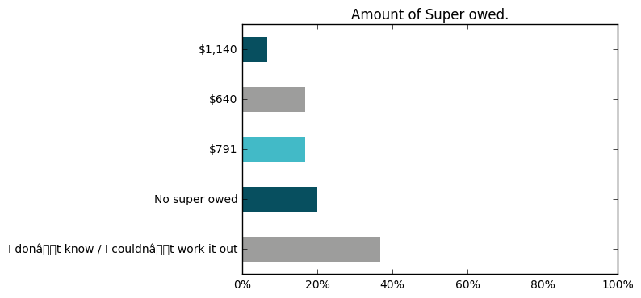

```python
print('Mean: ', superamt_results['%'].mean())
print('Standard Deviation: ', superamt_results['%'].std())

grapher_horizontal(superamt_results, ['%'], 'Amount of Super owed.', 'super_test2_graphs/')
```

### Task 2 Likert questions

```python
# Remove incomplete data rows (missing data from Loop11 raw export)
clean_completes_df = clean_df[clean_df["I'm confident I got the right answer."].notnull()]
len(clean_completes_df)
```

```
27
```

```python
# List of the standard likert scale question (e.g. agree, disagree...)
task2_agree_scale= ["I'm confident I got the right answer.",
              'I was given enough information about the documentation required to complete this form.',
              'I found the language used in the tool easy to understand.',
              'Overall I found this tool easy to use.',
              'I found it easy to navigate through this form.',
              'The buttons on this form behaved the way I expected.' ]

# Produce statistics for standard likert scale questions (with all scales)
task2_help_agree_likert_results = []

for q in task2_agree_scale:
    task2_help_agree_likert_results.append(pd.DataFrame(clean_completes_df[q].value_counts()))
    task2_help_agree_likert_results.append(pd.DataFrame(clean_completes_df[q].value_counts(normalize=True)))

# convert the flat list dataframe to columns
task2_help_agree_likert_results = pd.concat(task2_help_agree_likert_results , axis=1)

# Produce statistics for standard likert scale questions (with compacted scales)
compact_task2_help_agree_likert_results = []

for q in task2_agree_scale:
    temp = clean_completes_df[q].replace('Strongly agree', 'Agree', regex=True)
    temp = temp.replace('Strongly disagree', 'Disagree', regex=True)
    compact_task2_help_agree_likert_results.append(pd.DataFrame(temp.value_counts()))
    compact_task2_help_agree_likert_results.append(pd.DataFrame(temp.value_counts(normalize=True)))

compact_task2_help_agree_likert_results = pd.concat(compact_task2_help_agree_likert_results , axis=1) # convert the flat list dataframe to columns
compact_task2_help_agree_likert_results = compact_task2_help_agree_likert_results.reindex(['Agree', 'Neither agree nor disagree', 'Disagree'])

# Rename column titles
compact_task2_help_agree_likert_results.columns = ["I'm confident I got the right answer. (N)",
              "I'm confident I got the right answer. (%)",
              'I was given enough information about the documentation required to complete this form. (N)',
              'I was given enough information about the documentation required to complete this form. (%)',
              'I found the language used in the tool easy to understand. (N)',
              'I found the language used in the tool easy to understand. (%)',
              'Overall I found this tool easy to use. (N)',
              'Overall I found this tool easy to use. (%)',
              'I found it easy to navigate through this form. (N)',
              'I found it easy to navigate through this form. (%)',
              'The buttons on this form behaved the way I expected. (N)',
              'The buttons on this form behaved the way I expected. (%)']
compact_task2_help_agree_likert_results
```

|  | I'm confident I got the right answer. (N) | I'm confident I got the right answer. (%) | I was given enough information about the documentation required to complete this form. (N) | I was given enough information about the documentation required to complete this form. (%) | I found the language used in the tool easy to understand. (N) | I found the language used in the tool easy to understand. (%) | Overall I found this tool easy to use. (N) | Overall I found this tool easy to use. (%) | I found it easy to navigate through this form. (N) | I found it easy to navigate through this form. (%) | The buttons on this form behaved the way I expected. (N) | The buttons on this form behaved the way I expected. (%) |
| --- | --- | --- | --- | --- | --- | --- | --- | --- | --- | --- | --- | --- |
| Agree | 9 | 0.333333 | 9 | 0.333333 | 11 | 0.407407 | 10 | 0.370370 | 15 | 0.555556 | 14 | 0.518519 |
| Neither agree nor disagree | 4 | 0.148148 | 7 | 0.259259 | 9 | 0.333333 | 5 | 0.185185 | 5 | 0.185185 | 3 | 0.111111 |
| Disagree | 14 | 0.518519 | 11 | 0.407407 | 7 | 0.259259 | 12 | 0.444444 | 7 | 0.259259 | 10 | 0.370370 |

```
Mean:  0.3333333333333333
Standard Deviation:  0.07407407407407407
```

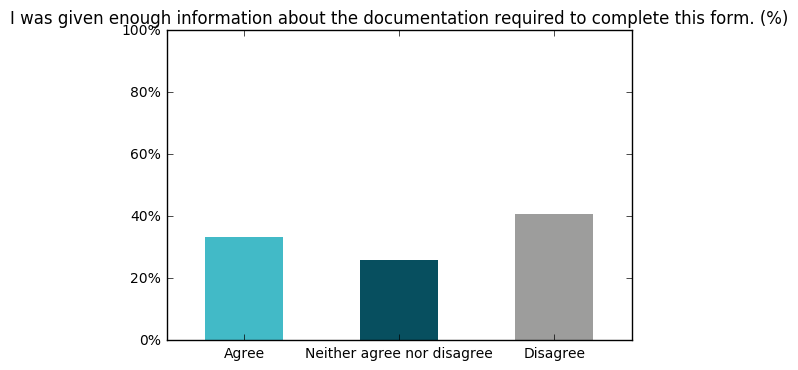

```python
print('Mean: ', compact_task2_help_agree_likert_results['I was given enough information about the documentation required to complete this form. (%)'].mean())
print ('Standard Deviation: ', compact_task2_help_agree_likert_results['I was given enough information about the documentation required to complete this form. (%)'].std())

grapher(compact_task2_help_agree_likert_results, ['I was given enough information about the documentation required to complete this form. (%)'], 'I was given enough information about the documentation required to complete this form. (%)', 'super_test2_graphs/')
```

```
Mean:  0.3333333333333333
Standard Deviation:  0.07407407407407407
```

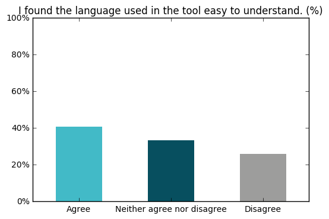

```python
print('Mean: ', compact_task2_help_agree_likert_results['I found the language used in the tool easy to understand. (%)'].mean())
print('Standard Deviation: ', compact_task2_help_agree_likert_results['I found the language used in the tool easy to understand. (%)'].std())

grapher(compact_task2_help_agree_likert_results, ['I found the language used in the tool easy to understand. (%)'], 'I found the language used in the tool easy to understand. (%)', 'super_test2_graphs/')
```

```
Mean:  0.3333333333333333
Standard Deviation:  0.1335389361282959
```

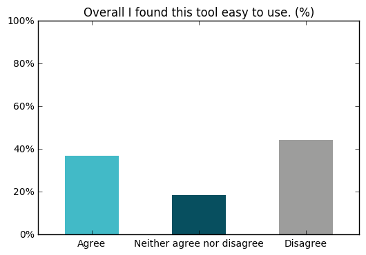

```python
print('Mean: ', compact_task2_help_agree_likert_results['Overall I found this tool easy to use. (%)'].mean())
print('Standard Deviation: ', compact_task2_help_agree_likert_results['Overall I found this tool easy to use. (%)'].std())

grapher(compact_task2_help_agree_likert_results, ['Overall I found this tool easy to use. (%)'], 'Overall I found this tool easy to use. (%)', 'super_test2_graphs/')
```

```
Mean:  0.3333333333333333
Standard Deviation:  0.19598157859737708
```

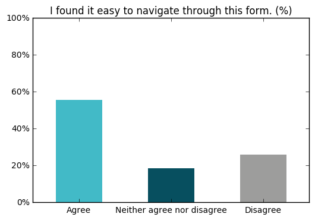

```python
print('Mean: ', compact_task2_help_agree_likert_results['I found it easy to navigate through this form. (%)'].mean())
print('Standard Deviation: ', compact_task2_help_agree_likert_results['I found it easy to navigate through this form. (%)'].std())

grapher(compact_task2_help_agree_likert_results, ['I found it easy to navigate through this form. (%)'], 'I found it easy to navigate through this form. (%)', 'super_test2_graphs/')
```

```
Mean:  0.3333333333333333
Standard Deviation:  0.20621349491963042
```

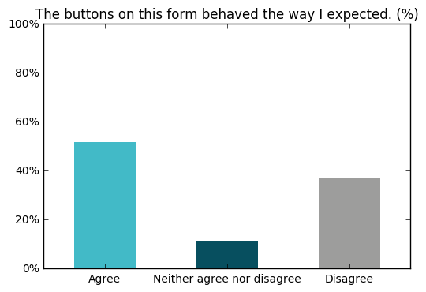

```python
print('Mean: ', compact_task2_help_agree_likert_results['The buttons on this form behaved the way I expected. (%)'].mean())
print('Standard Deviation: ', compact_task2_help_agree_likert_results['The buttons on this form behaved the way I expected. (%)'].std())

grapher(compact_task2_help_agree_likert_results, ['The buttons on this form behaved the way I expected. (%)'], 'The buttons on this form behaved the way I expected. (%)', 'super_test2_graphs/')
```

### What is your preference for entering employee salaries and wages?

```python
# What is your preference for entering employee salaries and wages?
timeperiod_results = []
timeperiod_results.append(pd.DataFrame(clean_df['What is your preference for entering employee salaries and wages?'].value_counts()))
timeperiod_results.append(pd.DataFrame(clean_df['What is your preference for entering employee salaries and wages?'].value_counts()/len(clean_df)))

timeperiod_results = pd.concat(timeperiod_results, axis=1)

timeperiod_results.columns = ['N','%']
timeperiod_results
```

|  | N | % |
| --- | --- | --- |
| Fortnightly | 11 | 0.366667 |
| Weekly | 8 | 0.266667 |
| Quarterly | 4 | 0.133333 |
| Monthly | 3 | 0.100000 |
| Annually | 1 | 0.033333 |

```python
# Other specified expectations for Information Use
timeperiod_other = []

timeperiod_other.append(pd.DataFrame(clean_df['Other, please specify.1']))
timeperiod_other = pd.concat(timeperiod_other, axis=1)
timeperiod_other = timeperiod_other[timeperiod_other['Other, please specify.1'].notnull()]

timeperiod_other
```

|  | Other, please specify.1 |
| --- | --- |
| 22 | ad hoc, I don't want to be limited by the system |
| 25 | will depend on period trying to calculate |
| 29 | None |

```
Mean:  0.18
Standard Deviation:  0.13457752825457567
```

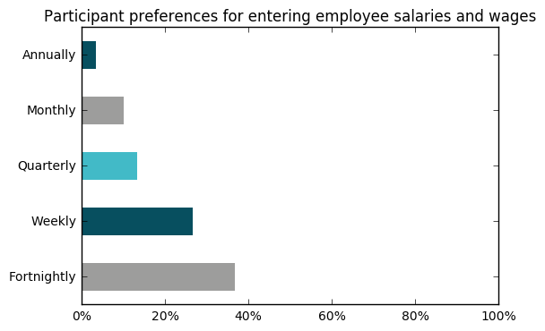

```python
print('Mean: ', timeperiod_results['%'].mean())
print('Standard Deviation: ', timeperiod_results['%'].std())

grapher_horizontal(timeperiod_results, ['%'], 'Participant preferences for entering employee salaries and wages', 'super_test2_graphs/')
```

### Select any of the help features you used.

```python
# Check there is no missing data in the column
len(clean_df['Select any of the help features you used. Please choose all that apply:']), N
```

```
(30, 30)
```

```python
# First break the strings up with , as the delimiter, and then tally the results as usual.
# Also replace NaN's with Other and remove null values

temp = clean_df['Select any of the help features you used. Please choose all that apply:'].fillna('Other')
broken_down = [sub.split(",") for sub in temp]
reshaped_list = [item.lstrip() for sublist in broken_down  for item in sublist]
set(reshaped_list)
test_df= pd.DataFrame(reshaped_list)

help_results = []
help_results.append(pd.DataFrame(test_df[0].value_counts()))
help_results.append(pd.DataFrame(test_df[0].value_counts()/len(clean_df)))

help_results = pd.concat(help_results, axis=1)
help_results.columns = ['Number','Fraction (from Sample size)']
help_results.index.name = 'SELECT ANY OF THE HELP FEATURES YOU USED'

help_results
```

| SELECT ANY OF THE HELP FEATURES YOU USED | Number | Fraction (from Sample size) |
| --- | --- | --- |
| None | 13 | 0.433333 |
| Help icon at the end of each question | 10 | 0.333333 |
| Help button at the top of the page | 7 | 0.233333 |
| Other | 1 | 0.033333 |
| Neither agree nor disagree | 1 | 0.033333 |

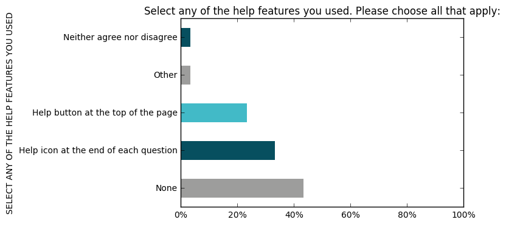

```python
grapher_horizontal(help_results, ['Fraction (from Sample size)'], 'Select any of the help features you used. Please choose all that apply:', 'super_test2_graphs/')
```

```python
# Other specified Help use
help_other = []

help_other.append(pd.DataFrame(clean_df['Other, please specify.2']))
help_other = pd.concat(help_other, axis=1)
help_other = help_other[help_other['Other, please specify.2'].notnull()]

help_other
```

|  | Other, please specify.2 |
| --- | --- |
| 4 | Pay the amount outstanding as per instructions |
| 8 | Pay the super guarantee charge amount |
| 14 | I use the Super Clearing house for employee su... |
| 16 | Pay the outstanding guaranteed charge |

```python
help_other['Other, please specify.2'][14]
```

```
'I use the Super Clearing house for employee super obligations'
```

### Task 2 Likert Questions (Help questions)

```python
# List of the standard likert scale question (e.g. agree, disagree...)
help_agree_scale= ['If you used the help features: I found it easy to locate the help icon at the end of each question.',
              'If you used the help features: I found the help content useful.']

# Produce statistics for standard likert scale questions (with all scales)
help_agree_likert_results = []

for q in help_agree_scale:
    help_agree_likert_results.append(pd.DataFrame(clean_completes_df[q].value_counts()))
    help_agree_likert_results.append(pd.DataFrame(clean_completes_df[q].value_counts(normalize=True)))

# convert the flat list dataframe to columns
help_agree_likert_results = pd.concat(help_agree_likert_results , axis=1)

# Produce statistics for standard likert scale questions (with compacted scales)
compact_help_agree_likert_results = []

for q in help_agree_scale:
    temp = clean_completes_df[q].replace('Strongly agree', 'Agree', regex=True)
    temp = temp.replace('Strongly disagree', 'Disagree', regex=True)
    compact_help_agree_likert_results.append(pd.DataFrame(temp.value_counts()))
    compact_help_agree_likert_results.append(pd.DataFrame(temp.value_counts(normalize=True)))

compact_help_agree_likert_results = pd.concat(compact_help_agree_likert_results , axis=1) # convert the flat list dataframe to columns
compact_help_agree_likert_results = compact_help_agree_likert_results.reindex(['Agree', 'Neither agree nor disagree', 'Disagree'])

# Rename column titles
compact_help_agree_likert_results.columns = ['If you used the help features: I found it easy to locate the help icon at the end of each question. (N)',
              'If you used the help features: I found it easy to locate the help icon at the end of each question. (%)',
              'If you used the help features: I found the help content useful. (N)',
              'If you used the help features: I found the help content useful. (%)',
]
compact_help_agree_likert_results
```

|  | If you used the help features: I found it easy to locate the help icon at the end of each question. (N) | If you used the help features: I found it easy to locate the help icon at the end of each question. (%) | If you used the help features: I found the help content useful. (N) | If you used the help features: I found the help content useful. (%) |
| --- | --- | --- | --- | --- |
| Agree | 9 | 0.6 | 6 | 0.461538 |
| Neither agree nor disagree | 3 | 0.2 | 6 | 0.461538 |
| Disagree | 3 | 0.2 | 1 | 0.076923 |

```
Mean:  0.3333333333333333
Standard Deviation:  0.23094010767585027
```

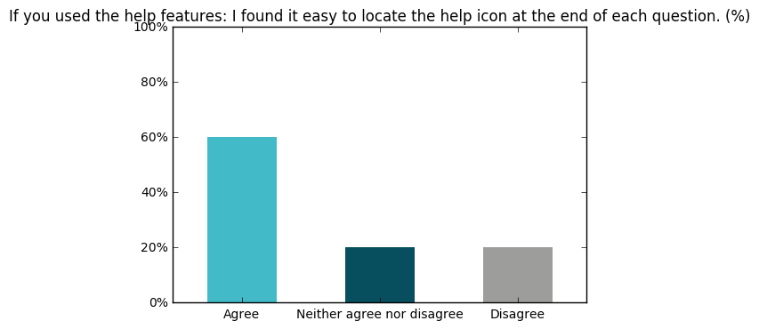

```python
print('Mean: ', compact_help_agree_likert_results['If you used the help features: I found it easy to locate the help icon at the end of each question. (%)'].mean())
print('Standard Deviation: ', compact_help_agree_likert_results['If you used the help features: I found it easy to locate the help icon at the end of each question. (%)'].std())

grapher(compact_help_agree_likert_results, ['If you used the help features: I found it easy to locate the help icon at the end of each question. (%)'], 'If you used the help features: I found it easy to locate the help icon at the end of each question. (%)', 'super_test2_graphs/')
```

```
Mean:  0.3333333333333333
Standard Deviation:  0.22205779584216376
```

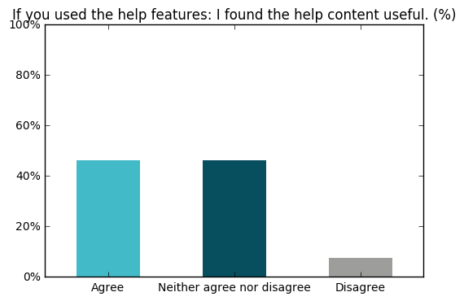

```python
print('Mean: ', compact_help_agree_likert_results['If you used the help features: I found the help content useful. (%)'].mean())
print('Standard Deviation: ', compact_help_agree_likert_results['If you used the help features: I found the help content useful. (%)'].std())

grapher(compact_help_agree_likert_results, ['If you used the help features: I found the help content useful. (%)'], 'If you used the help features: I found the help content useful. (%)', 'super_test2_graphs/')
```

### I was aware that there was an additional help button at the top of the page.

```python
# Check there is no missing data in the column.
len(clean_df['I was aware that there was an additional help button at the top of the page.'].notnull())
```

```
30
```

```python
# Help icon awareness
help_icon_results = []
help_icon_results.append(pd.DataFrame(clean_df['I was aware that there was an additional help button at the top of the page.'].value_counts()))
help_icon_results.append(pd.DataFrame(clean_df['I was aware that there was an additional help button at the top of the page.'].value_counts()/len(clean_df)))

help_icon_results = pd.concat(help_icon_results, axis=1)

help_icon_results.columns = ['N','%']
help_icon_results
```

|  | N | % |
| --- | --- | --- |
| No | 21 | 0.700000 |
| Yes | 5 | 0.166667 |
| I'm unsure | 3 | 0.100000 |

```
Mean:  0.3222222222222222
Standard Deviation:  0.3288588574877498
```

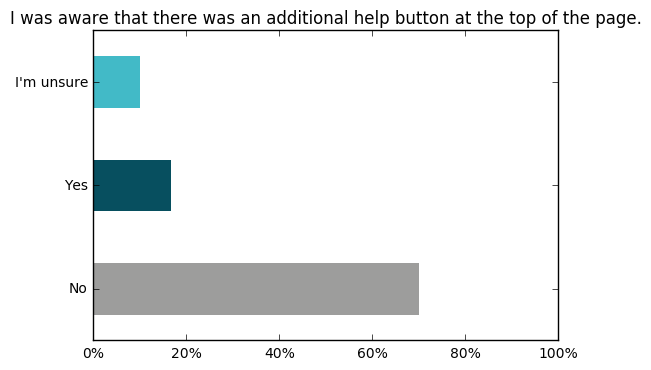

```python
print('Mean: ', help_icon_results['%'].mean())
print('Standard Deviation: ', help_icon_results['%'].std())

grapher_horizontal(help_icon_results, ['%'], 'I was aware that there was an additional help button at the top of the page.', 'super_test2_graphs/')
```

## Task 3 Questions

### Based on the information provided on the screen, what are the next steps you would take?

```python
# First break the strings up with , as the delimiter, and then tally the results as usual.
# Also replace NaN's with Other and remove null values

temp = clean_df['Based on the information provided on screen, what are the next steps you would take? Please select all that apply:'].fillna('Other')
broken_down = [sub.split(",") for sub in temp]
reshaped_list = [item.lstrip() for sublist in broken_down  for item in sublist]
set(reshaped_list)
test_df= pd.DataFrame(reshaped_list)

next_steps = []
next_steps.append(pd.DataFrame(test_df[0].value_counts()))
next_steps.append(pd.DataFrame(test_df[0].value_counts()/len(clean_df)))

next_steps = pd.concat(next_steps, axis=1)
next_steps.columns = ['Number','Fraction (from Sample size)']
next_steps.index.name = 'NEXT STEPS TO TAKE - EXPECTATIONS'

next_steps
```

| NEXT STEPS TO TAKE - EXPECTATIONS | Number | Fraction (from Sample size) |
| --- | --- | --- |
| Print and sign the generated statement and send it to the ATO | 24 | 0.800000 |
| Generate a statement and save it | 12 | 0.400000 |
| Give this information to my employee/s | 2 | 0.066667 |
| Contact the ATO or tax agent | 2 | 0.066667 |
| Print and sign the generated statement and send it to the super fund | 2 | 0.066667 |
| Other | 1 | 0.033333 |
| Contact the super fund | 1 | 0.033333 |

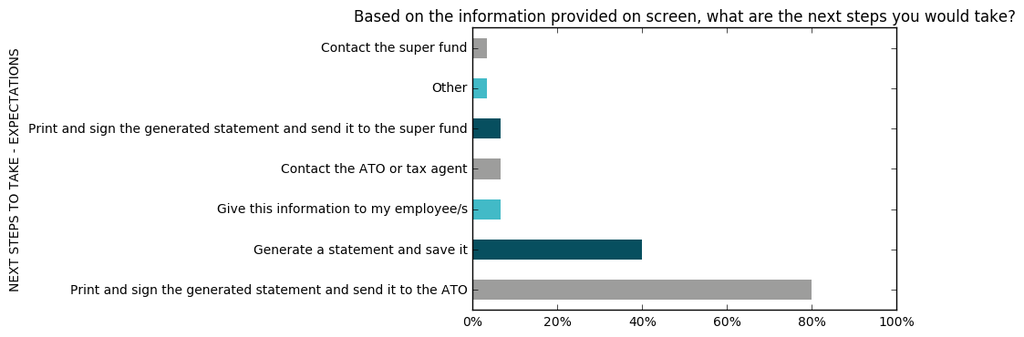

```python
grapher_horizontal(next_steps, ['Fraction (from Sample size)'], 'Based on the information provided on screen, what are the next steps you would take?', 'super_test2_graphs/')
```

```python
# Other specified expectations for Information Use
next_steps_other = []

next_steps_other.append(pd.DataFrame(clean_df['Other, please specify.2']))
next_steps_other = pd.concat(next_steps_other, axis=1)
next_steps_other = next_steps_other[next_steps_other['Other, please specify.2'].notnull()]

next_steps_other
```

|  | Other, please specify.2 |
| --- | --- |
| 4 | Pay the amount outstanding as per instructions |
| 8 | Pay the super guarantee charge amount |
| 14 | I use the Super Clearing house for employee su... |
| 16 | Pay the outstanding guaranteed charge |

```python
next_steps_other['Other, please specify.2'][14]
```

```
'I use the Super Clearing house for employee super obligations'
```

### If you were going to send your report to the ATO, how would you do that?

```python
# Check there is no missing data in the column
len(clean_df['If you were going to send your report to the ATO, how would you do that?'])
```

```
30
```

```python
# How would you send your report to the ATO?
report_results = []
report_results.append(pd.DataFrame(clean_df['If you were going to send your report to the ATO, how would you do that?'].value_counts()))
report_results.append(pd.DataFrame(clean_df['If you were going to send your report to the ATO, how would you do that?'].value_counts()/len(clean_df)))

report_results = pd.concat(report_results, axis=1)

report_results.columns = ['N','%']
report_results
```

|  | N | % |
| --- | --- | --- |
| Generate an SGC statement and print the statement | 17 | 0.566667 |
| Use the print-friendly button to print the summary page | 7 | 0.233333 |
| I'm unsure | 3 | 0.100000 |
| None of the above | 2 | 0.066667 |

```
Mean:  0.24166666666666667
Standard Deviation:  0.22831913986705016
```

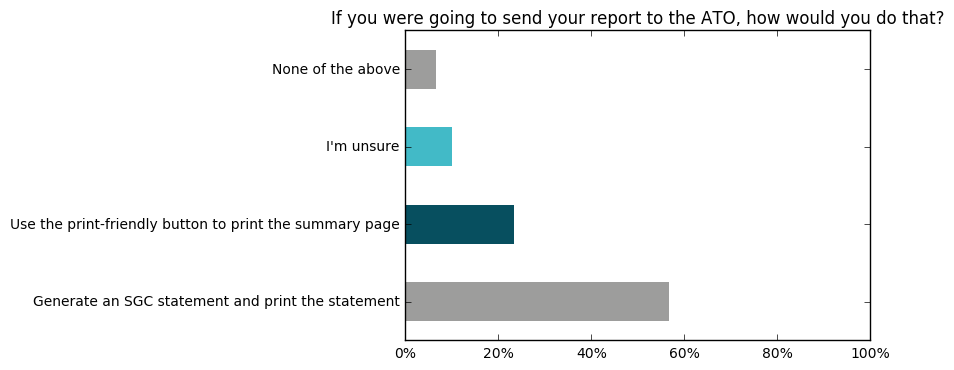

```python
print('Mean: ', report_results['%'].mean())
print('Standard Deviation: ', report_results['%'].std())

grapher_horizontal(report_results, ['%'], 'If you were going to send your report to the ATO, how would you do that?', 'super_test2_graphs/')
```

### Task 3 Likert Questions

```python
# Remove incomplete data rows (missing data from Loop11 raw export)
clean_completes_df = clean_df[clean_df['I found the summary easy to understand.'].notnull()]
len(clean_completes_df)
```

```
29
```

```python
# List of the standard likert scale question (e.g. agree, disagree...)
task3_agree_scale= ['I found the summary easy to understand.',
              'I feel confident about the next steps I need to take after using this calculator.']

# Produce statistics for standard likert scale questions (with all scales)
task3_agree_likert_results = []

for q in task3_agree_scale:
    task3_agree_likert_results.append(pd.DataFrame(clean_completes_df[q].value_counts()))
    task3_agree_likert_results.append(pd.DataFrame(clean_completes_df[q].value_counts(normalize=True)))

# convert the flat list dataframe to columns
task3_agree_likert_results = pd.concat(task3_agree_likert_results , axis=1)

# Produce statistics for standard likert scale questions (with compacted scales)
compact_task3_agree_likert_results = []

for q in task3_agree_scale:
    temp = clean_completes_df[q].replace('Strongly agree', 'Agree', regex=True)
    temp = temp.replace('Strongly disagree', 'Disagree', regex=True)
    compact_task3_agree_likert_results.append(pd.DataFrame(temp.value_counts()))
    compact_task3_agree_likert_results.append(pd.DataFrame(temp.value_counts(normalize=True)))

compact_task3_agree_likert_results = pd.concat(compact_task3_agree_likert_results , axis=1) # convert the flat list dataframe to columns
compact_task3_agree_likert_results = compact_task3_agree_likert_results.reindex(['Agree', 'Neither agree nor disagree', 'Disagree'])

# Rename column titles
compact_task3_agree_likert_results.columns = ['I found the summary easy to understand. (N)',
              'I found the summary easy to understand. (%)',
              'I feel confident about the next steps I need to take after using this calculator. (N)',
              'I feel confident about the next steps I need to take after using this calculator. (%)']
compact_task3_agree_likert_results
```

|  | I found the summary easy to understand. (N) | I found the summary easy to understand. (%) | I feel confident about the next steps I need to take after using this calculator. (N) | I feel confident about the next steps I need to take after using this calculator. (%) |
| --- | --- | --- | --- | --- |
| Agree | 17 | 0.586207 | 17 | 0.586207 |
| Neither agree nor disagree | 5 | 0.172414 | 5 | 0.172414 |
| Disagree | 7 | 0.241379 | 7 | 0.241379 |

```
Mean:  0.3333333333333333
Standard Deviation:  0.22169312094236673
```

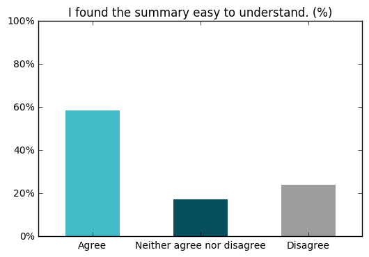

```python
print('Mean: ', compact_task3_agree_likert_results['I found the summary easy to understand. (%)'].mean())
print('Standard Deviation: ', compact_task3_agree_likert_results['I found the summary easy to understand. (%)'].std())

grapher(compact_task3_agree_likert_results, ['I found the summary easy to understand. (%)'], 'I found the summary easy to understand. (%)', 'super_test2_graphs/')
```

```
Mean:  0.3333333333333333
Standard Deviation:  0.22169312094236673
```

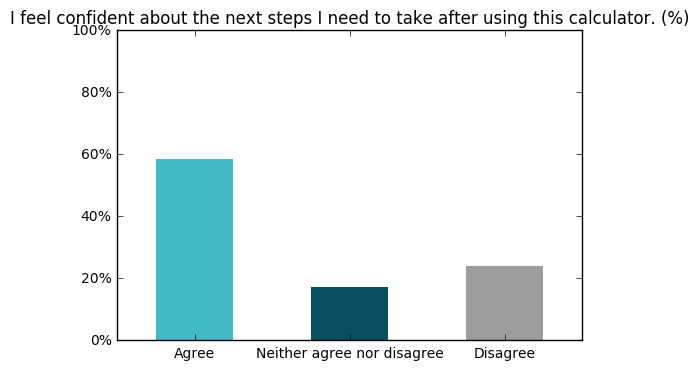

```python
print('Mean: ', compact_task3_agree_likert_results['I feel confident about the next steps I need to take after using this calculator. (%)'].mean())
print('Standard Deviation: ', compact_task3_agree_likert_results['I feel confident about the next steps I need to take after using this calculator. (%)'].std())

grapher(compact_task3_agree_likert_results, ['I feel confident about the next steps I need to take after using this calculator. (%)'], 'I feel confident about the next steps I need to take after using this calculator. (%)', 'super_test2_graphs/')
```